# Outsourcing Report template

### Arrival in the UK

```r
bornuk_statistics <- data %>%
  # get values of labels
  mutate_all(haven::as_factor) %>%
  group_by(outsourcing_status, BORNUK) %>%
  summarise(
    Frequency = n()
  ) %>%
  mutate(
    Sum = sum(Frequency),
    Percentage = 100 * (Frequency / Sum)
  )

readr::write_csv(bornuk_statistics, file="../outputs/data/arrival_in_UK_stats.csv")
```

```r
categories <- as.vector(unique(haven::as_factor(data$BORNUK)))
non_categories <- categories[!(categories %in% "I was born in the UK")]

# Will throw NA warning. I think this OK but investigate how to avoid the problem
summary_table <- data %>%
  mutate(
    BORNUK = haven::as_factor(BORNUK)
  ) %>%
  mutate(
    BORNUK = forcats::fct_collapse(as.character(BORNUK),
                                      "Born in UK" = "I was born in the UK",
                                      "Not born in UK" = non_categories)
  ) %>%
  group_by(outsourcing_status, BORNUK) %>%
  summarise(
    n = n()
  ) %>%
  mutate(
    Sum = sum(n),
    Percentage = 100 * (n / Sum)
  )

domain <- "BORNUK"
category_1 <- "Born in UK"
category_2 <- "Not born in UK"

group_1 <- t(tibble("present"=summary_table[which(summary_table[domain]==category_1 &
                                 summary_table["outsourcing_status"]=="Outsourced"),"n"],
"not present" = summary_table[which(summary_table[domain]==category_2 &
                                 summary_table["outsourcing_status"]=="Outsourced"),"n"]
))

group_2 <- t(tibble("present"=summary_table[which(summary_table[domain]==category_1 &
                                 summary_table["outsourcing_status"]=="Not outsourced"),"n"],
"not present" = summary_table[which(summary_table[domain]==category_2 &
                                 summary_table["outsourcing_status"]=="Not outsourced"),"n"]
))


comp_mat <- as.matrix(cbind(group_2, group_1)) # matrix for crosstable
x2 <- gmodels::CrossTable(comp_mat, fisher=TRUE, chisq = TRUE)
 # (chi-square = `r round(x2[["chisq"]][["statistic"]][["X-squared"]],2)`, *p* = `r ifelse(x2[["chisq"]][["p.value"]] < .001, "< .001", paste0("= ", round(``x2[["chisq"]][["p.value"]],2))`).
```

A greater proportion of outsourced workers were not born in the UK (24.06%) compared to non-outsourced workers (13.6%).[^17] This difference is statistically significant; **outsourced workers are 2.01 times more likely to have been born outside the UK than non-outsourced workers.**

```r
bornuk_statistics %>%
  knitr::kable(.,digits = 2) %>%
  kable_styling(full_width = F)
```

| outsourcing_status | BORNUK | Frequency | Sum | Percentage |
| --- | --- | --- | --- | --- |
| Not outsourced | I was born in the UK | 7320 | 8472 | 86.40 |
| Not outsourced | Within the last year | 115 | 8472 | 1.36 |
| Not outsourced | Within the last 3 years | 135 | 8472 | 1.59 |
| Not outsourced | Within the last 5 years | 116 | 8472 | 1.37 |
| Not outsourced | Within the last 10 years | 183 | 8472 | 2.16 |
| Not outsourced | Within the last 15 years | 137 | 8472 | 1.62 |
| Not outsourced | Within the last 20 years | 127 | 8472 | 1.50 |
| Not outsourced | Within the last 30 years | 103 | 8472 | 1.22 |
| Not outsourced | More than 30 years ago | 149 | 8472 | 1.76 |
| Not outsourced | Prefer not to say | 87 | 8472 | 1.03 |
| Outsourced | I was born in the UK | 1278 | 1683 | 75.94 |
| Outsourced | Within the last year | 65 | 1683 | 3.86 |
| Outsourced | Within the last 3 years | 45 | 1683 | 2.67 |
| Outsourced | Within the last 5 years | 40 | 1683 | 2.38 |
| Outsourced | Within the last 10 years | 71 | 1683 | 4.22 |
| Outsourced | Within the last 15 years | 53 | 1683 | 3.15 |
| Outsourced | Within the last 20 years | 44 | 1683 | 2.61 |
| Outsourced | Within the last 30 years | 14 | 1683 | 0.83 |
| Outsourced | More than 30 years ago | 39 | 1683 | 2.32 |
| Outsourced | Prefer not to say | 34 | 1683 | 2.02 |

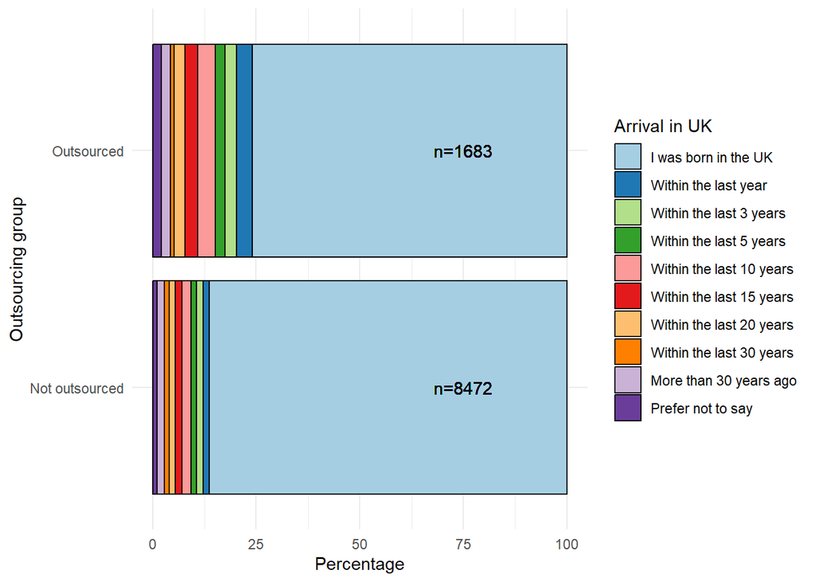

```r
bornuk_statistics %>%
  ggplot(., aes(outsourcing_status, Percentage, fill = BORNUK)) +
  geom_col(colour="black") +
  annotate("text", x = bornuk_statistics$outsourcing_status, y = 75, label = paste0("n=",bornuk_statistics$Sum)) +
  coord_flip() +
  scale_fill_manual(values=many_colours, name="Arrival in UK") +
  theme_minimal() +
  xlab("Outsourcing group")
```

#### Paysplit

```r
bornuk_summary_paysplit <- data %>%
  group_by(outsourcing_status, income_group, BORNUK_labelled) %>%
  summarise(
    n = n(),
    Frequency = sum(NatRepemployees)
  ) %>%
  mutate(
    N = sum(n),
    Sum = sum(Frequency),
    Percentage = 100 * (Frequency / Sum)
  )

readr::write_csv(bornuk_summary_paysplit, file = "../outputs/data/bornuk_stats_paysplit_1.csv")
```

```r
mod <- glm(outsourcing_status ~ income_group * BORNUK_labelled, data, weights = NatRepemployees, family="binomial")
summary(mod)
```

```
Call:
glm(formula = outsourcing_status ~ income_group * BORNUK_labelled,
    family = "binomial", data = data, weights = NatRepemployees)

Coefficients:
                                                        Estimate Std. Error
(Intercept)                                             -1.80357    0.04344
income_groupLow                                          0.22862    0.06439
BORNUK_labelledWithin the last year                      1.28978    0.25307
BORNUK_labelledWithin the last 3 years                   0.68932    0.23063
BORNUK_labelledWithin the last 5 years                   0.54565    0.24814
BORNUK_labelledWithin the last 10 years                  0.74566    0.18405
BORNUK_labelledWithin the last 15 years                  1.05016    0.18554
BORNUK_labelledWithin the last 20 years                  0.99745    0.20348
BORNUK_labelledWithin the last 30 years                 -1.33247    0.53396
BORNUK_labelledMore than 30 years ago                    0.43879    0.23670
BORNUK_labelledPrefer not to say                         0.84084    0.44469
income_groupLow:BORNUK_labelledWithin the last year     -0.38239    0.35255
income_groupLow:BORNUK_labelledWithin the last 3 years  -0.41813    0.39148
income_groupLow:BORNUK_labelledWithin the last 5 years   0.12118    0.42110
income_groupLow:BORNUK_labelledWithin the last 10 years  0.24893    0.28633
income_groupLow:BORNUK_labelledWithin the last 15 years -0.95025    0.38000
income_groupLow:BORNUK_labelledWithin the last 20 years -0.84991    0.43888
income_groupLow:BORNUK_labelledWithin the last 30 years  1.75447    0.69940
income_groupLow:BORNUK_labelledMore than 30 years ago    0.54466    0.35281
income_groupLow:BORNUK_labelledPrefer not to say        -0.12256    0.63991
                                                        z value Pr(>|z|)
(Intercept)                                             -41.516  < 2e-16 ***
income_groupLow                                           3.551 0.000384 ***
BORNUK_labelledWithin the last year                       5.096 3.46e-07 ***
BORNUK_labelledWithin the last 3 years                    2.989 0.002800 **
BORNUK_labelledWithin the last 5 years                    2.199 0.027883 *
BORNUK_labelledWithin the last 10 years                   4.051 5.09e-05 ***
BORNUK_labelledWithin the last 15 years                   5.660 1.51e-08 ***
BORNUK_labelledWithin the last 20 years                   4.902 9.49e-07 ***
BORNUK_labelledWithin the last 30 years                  -2.495 0.012579 *
BORNUK_labelledMore than 30 years ago                     1.854 0.063776 .
BORNUK_labelledPrefer not to say                          1.891 0.058647 .
income_groupLow:BORNUK_labelledWithin the last year      -1.085 0.278074
income_groupLow:BORNUK_labelledWithin the last 3 years   -1.068 0.285484
income_groupLow:BORNUK_labelledWithin the last 5 years    0.288 0.773525
income_groupLow:BORNUK_labelledWithin the last 10 years   0.869 0.384622
income_groupLow:BORNUK_labelledWithin the last 15 years  -2.501 0.012396 *
income_groupLow:BORNUK_labelledWithin the last 20 years  -1.937 0.052802 .
income_groupLow:BORNUK_labelledWithin the last 30 years   2.509 0.012123 *
income_groupLow:BORNUK_labelledMore than 30 years ago     1.544 0.122644
income_groupLow:BORNUK_labelledPrefer not to say         -0.192 0.848114
---
Signif. codes:  0 '***' 0.001 '**' 0.01 '*' 0.05 '.' 0.1 ' ' 1

(Dispersion parameter for binomial family taken to be 1)

    Null deviance: 8150.5  on 8942  degrees of freedom
Residual deviance: 7991.6  on 8923  degrees of freedom
  (1212 observations deleted due to missingness)
AIC: 8937.4

Number of Fisher Scoring iterations: 5
```

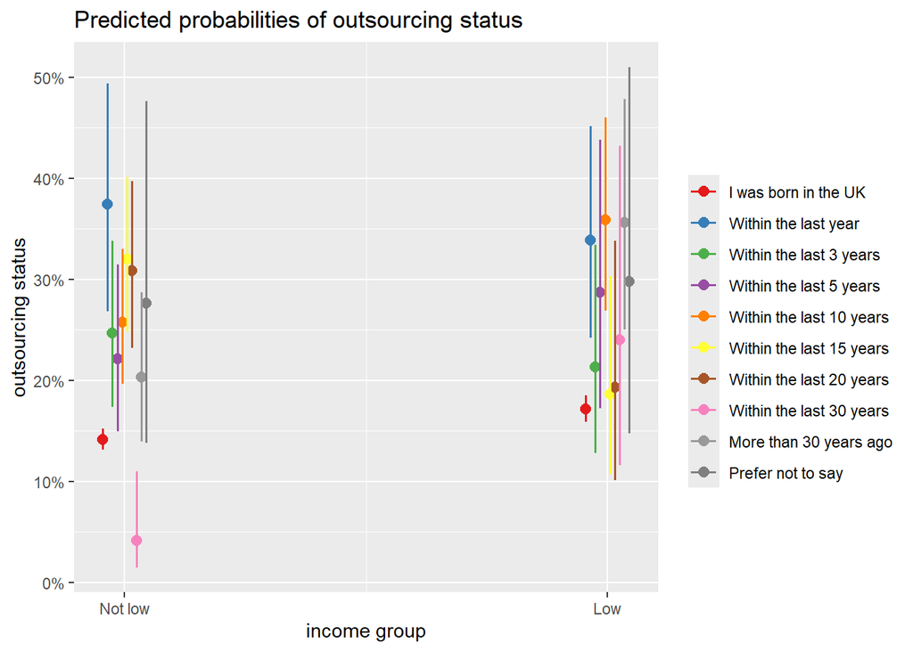

```r
# To me this indicates that htere is main effect - arrival time pre
sjPlot::plot_model(mod, type = "int", legend.title = "")
```

**Note**

We should test this with a more complex model that includes covariates

The plot below shows the percentage of outrouced and non-outsourced people by income group and arrival time.

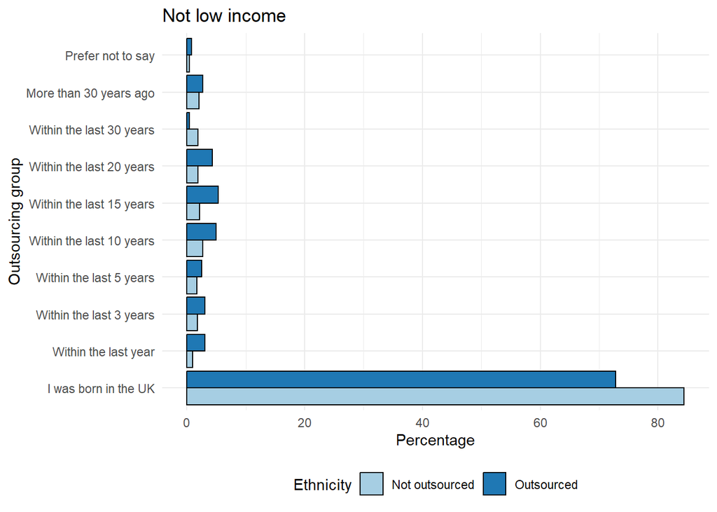

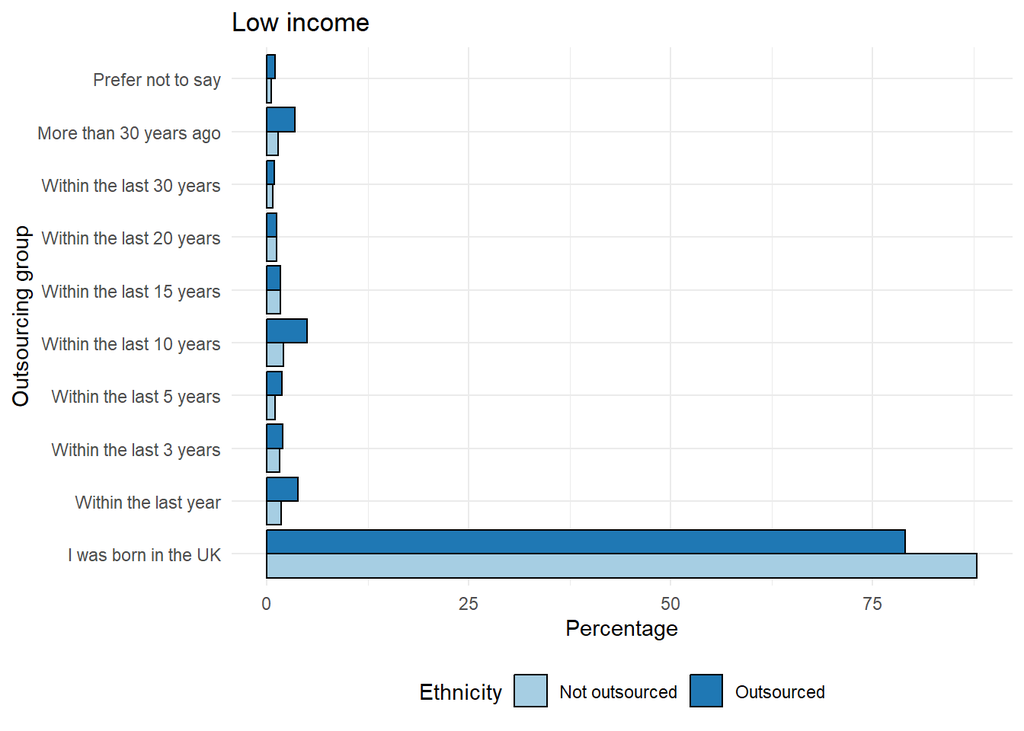

```r
temp_data <-  bornuk_summary_paysplit %>%
  drop_na(income_group)

for(group in unique(temp_data$income_group)){
  plot_data <- temp_data %>%
    filter(income_group==group)

  plot <- plot_data %>%
    ggplot(., aes(BORNUK_labelled, Percentage, fill = outsourcing_status)) +
      geom_col(colour="black", position = position_dodge()) +
      #annotate("text", x = ethnicity_statistics$outsourcing_status, y = 75, label = paste0("n=",ethnicity_statistics$Sum)) +
      coord_flip() +
      scale_fill_manual(values = many_colours, name = "Ethnicity") +
      xlab("Outsourcing group") +
      theme_minimal() +
    theme(
      legend.position = "bottom"
    ) +
    ggtitle(paste0(group, " income"))


  print(plot)
}
```

```r
# ethnicity_summary_paysplit %>%
#   drop_na(income_group) %>%
#   ggplot(., aes(outsourcing_status, Percentage, fill = Ethnicity_short)) +
#   facet_grid(rows=~income_group) +
#   geom_col(colour="black") +
#   #annotate("text", x = ethnicity_statistics$outsourcing_status, y = 75, label = paste0("n=",ethnicity_statistics$Sum)) +
#   coord_flip() +
#   scale_fill_manual(values = many_colours, name = "Ethnicity") +
#   xlab("Outsourcing group") +
#   theme_minimal() +
#   theme(
#     legend.position = "bottom"
#   )
```

### Interaction: Ethnicity and arrival in UK[^18]

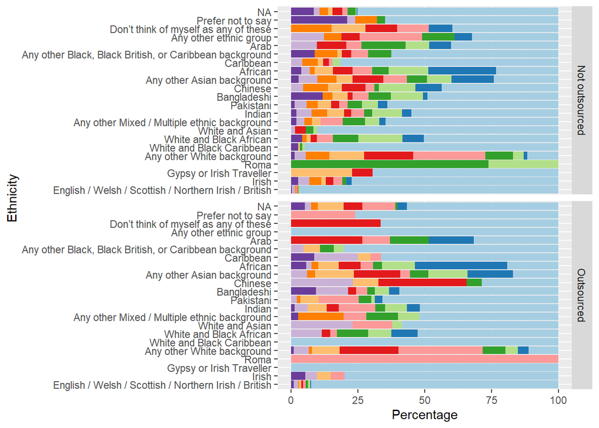

```r
temp_df <- data %>%
  # filter(outsourcing_status=="Outsourced") %>%
  mutate(
    Ethnicity = haven::as_factor(Ethnicity),
    BORNUK = haven::as_factor(BORNUK)
  )

# mytable <- table(temp_df$BORNUK,temp_df$Ethnicity)
# tab <- as.data.frame(prop.table(mytable))

# int_summary <- temp_df %>%
#   group_by(BORNUK, Ethnicity) %>%
#   summarise(
#     Frequency = sum(NatRepemployees)
#   ) %>%
#   mutate(
#     Percentage = 100 * (Frequency/sum(Frequency))
#   )
#
# int_summary %>%
#   ggplot(., aes(BORNUK, Percentage, fill = Ethnicity)) +
#   geom_col() +
#   coord_flip() +
#   theme(legend.position = "none") +
#   scale_fill_manual(values = many_colours)
#
# int_summary %>%
#   ggplot(., aes(BORNUK, Percentage, fill = Ethnicity)) +
#   geom_col() +
#   coord_flip() +
#   scale_fill_manual(values = many_colours)
#   # theme(legend.position = "none")


int_summary_2 <- temp_df %>%
  group_by(outsourcing_status, Ethnicity, BORNUK) %>%
  summarise(
    Frequency = sum(NatRepemployees)
  ) %>%
  mutate(
    Percentage = 100 * (Frequency/sum(Frequency))
  )

int_summary_2 %>%
  ggplot(., aes(Ethnicity, Percentage, fill = BORNUK)) +
  facet_grid(rows=vars(outsourcing_status)) +
  geom_col() +
  coord_flip() +
  theme(legend.position = "none") +
  scale_fill_manual(values = many_colours)
```

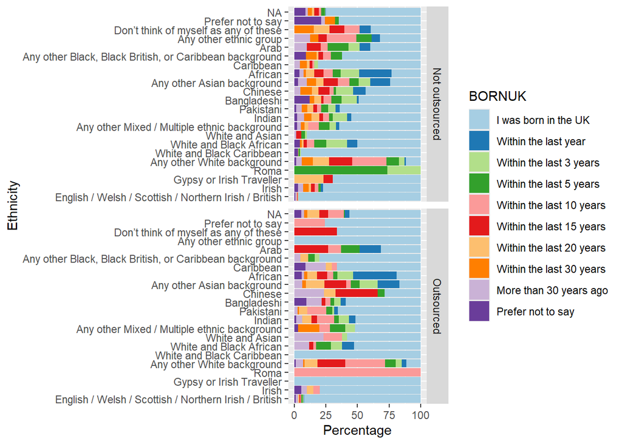

```r
int_summary_2 %>%
  ggplot(., aes(Ethnicity, Percentage, fill = BORNUK)) +
    facet_grid(rows=vars(outsourcing_status)) +
  geom_col() +
  coord_flip() +
  scale_fill_manual(values = many_colours)
```

```r
  # theme(legend.position = "none")

readr::write_csv(int_summary_2, file="../outputs/data/interaction_ethnicity_arrival_in_UK_stats.csv")
```

For the following ethnicites, **more than 50%** were born in the UK:

- NA
- Prefer not to say
- Any other Black, Black British, or Caribbean background
- Caribbean
- Pakistani
- Any other Mixed/Multiple ethnic background
- White and Asian
- White and Black Caribbean
- Gypsy or Irish Traveller
- Irish
- English/Welsh/Scottish/Northern Irish/British

For the following ethnicities **around 50%** were born in the UK, with remaining 50% split across arrival times:

- Don’t think of myself as any of these (second largest proportion within the last 15 years)
- Any other ethnic group (2nd largest proportion wihtin the last 10 years)
- Bangladeshi (2nd largest proprotion prefer not to say)
- Indian (2nd largest proportion wthin the last 3 years)
- White and Black African (2nd largest proportion within the last 3 years)

For the following ethnicities, **less than 50%** were born in the UK:

- Arab
- African (largest proportion within the last year)
- Any other Asian background (2nd an 3rd largest proportions are within the last year and within the last 15 years)
- Chinese (2nd and 3rd largest proportions are within the last 3 years, wihtin the last 15 years)
- Any other White background (largest proportion within the last 10 years)
- Roma (largest proportion within the last 5 years)

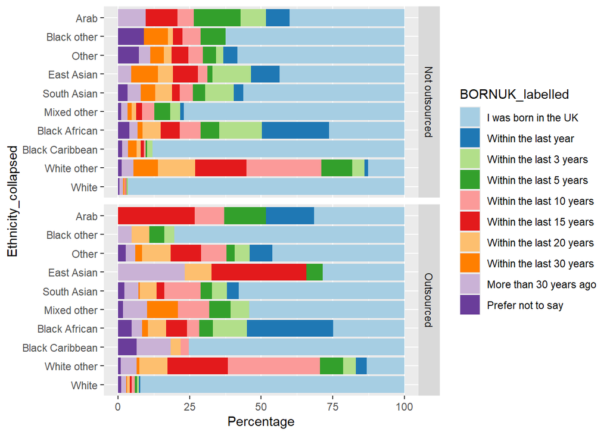

```r
  # filter(outsourcing_status=="Outsourced") %>%
  # mutate(
  #   Ethnicity = haven::as_factor(Ethnicity),
  #   BORNUK = haven::as_factor(BORNUK)
  # )

# mytable <- table(temp_df$BORNUK,temp_df$Ethnicity)
# tab <- as.data.frame(prop.table(mytable))

# int_summary <- temp_df %>%
#   group_by(BORNUK, Ethnicity) %>%
#   summarise(
#     Frequency = sum(NatRepemployees)
#   ) %>%
#   mutate(
#     Percentage = 100 * (Frequency/sum(Frequency))
#   )
#
# int_summary %>%
#   ggplot(., aes(BORNUK, Percentage, fill = Ethnicity)) +
#   geom_col() +
#   coord_flip() +
#   theme(legend.position = "none") +
#   scale_fill_manual(values = many_colours)
#
# int_summary %>%
#   ggplot(., aes(BORNUK, Percentage, fill = Ethnicity)) +
#   geom_col() +
#   coord_flip() +
#   scale_fill_manual(values = many_colours)
#   # theme(legend.position = "none")


int_summary_2 <- data %>%
  group_by(outsourcing_status, Ethnicity_collapsed, BORNUK_labelled) %>%
  summarise(
    Frequency = sum(NatRepemployees)
  ) %>%
  mutate(
    Percentage = 100 * (Frequency/sum(Frequency))
  )

# int_summary_2 %>%
#   ggplot(., aes(Ethnicity_collapsed, Percentage, fill = BORNUK_labelled)) +
#   facet_grid(rows=vars(outsourcing_status)) +
#   geom_col() +
#   coord_flip() +
#   theme(legend.position = "none") +
#   scale_fill_manual(values = many_colours)

int_summary_2 %>%
  ggplot(., aes(Ethnicity_collapsed, Percentage, fill = BORNUK_labelled)) +
    facet_grid(rows=vars(outsourcing_status)) +
  geom_col() +
  coord_flip() +
  scale_fill_manual(values = many_colours)
```

```r
  # theme(legend.position = "none")
```

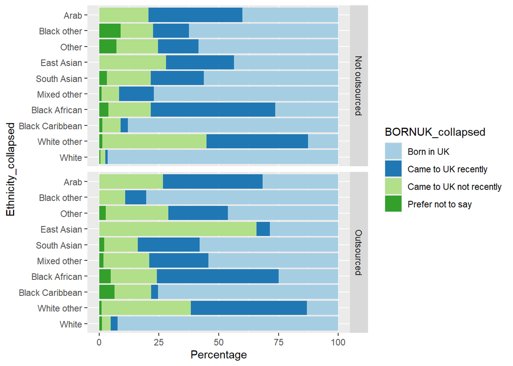

```r
data <- data %>%
  mutate(
    BORNUK_collapsed = forcats::fct_collapse(BORNUK_labelled,
                                            "Born in UK" = "I was born in the UK",
                                            "Came to UK recently" = c("Within the last year",
                                                                       "Within the last 3 years",
                                                                       "Within the last 5 years",
                                                                       "Within the last 10 years"),
                                            "Came to UK not recently" =  c("Within the last 15 years",
                                                                           "Within the last 20 years",
                                                                           "Within the last 30 years",
                                                                           "More than 30 years ago"),
                                            "Prefer not to say" = c("Prefer not to say")
    )
  )

int_summary_3 <- data %>%
  group_by(outsourcing_status, Ethnicity_collapsed, BORNUK_collapsed) %>%
  summarise(
    Frequency = sum(NatRepemployees)
  ) %>%
  mutate(
    Percentage = 100 * (Frequency/sum(Frequency))
  )

int_summary_3 %>%
  ggplot(., aes(Ethnicity_collapsed, Percentage, fill = BORNUK_collapsed)) +
    facet_grid(rows=vars(outsourcing_status)) +
  geom_col() +
  coord_flip() +
  scale_fill_manual(values = many_colours)
```

```r
# mod <- glm(outsourcing_status ~ Ethnicity_collapsed*BORNUK_collapsed, data, family="binomial", weight = NatRepemployees)
# summary(mod)
# emmeans(mod, specs = "Ethnicity_collapsed", by ="BORNUK_collapsed")
# sjPlot::plot_model(mod, type = "int", legend.title = "", terms = c("outsourcing_status","BORNUK_collapsed","Ethnicity_collapsed ['Black African]"))
#
```

### Gender[^19]

```r
gender_statistics <- data %>%
  # get values of labels
  mutate_all(haven::as_factor) %>%
  group_by(outsourcing_status, Gender) %>%
  summarise(
    Frequency = n()
  ) %>%
  mutate(
    Percentage = 100 * (Frequency / sum(Frequency))
  )

readr::write_csv(gender_statistics, file="../outputs/data/gender_statistics.csv")
```

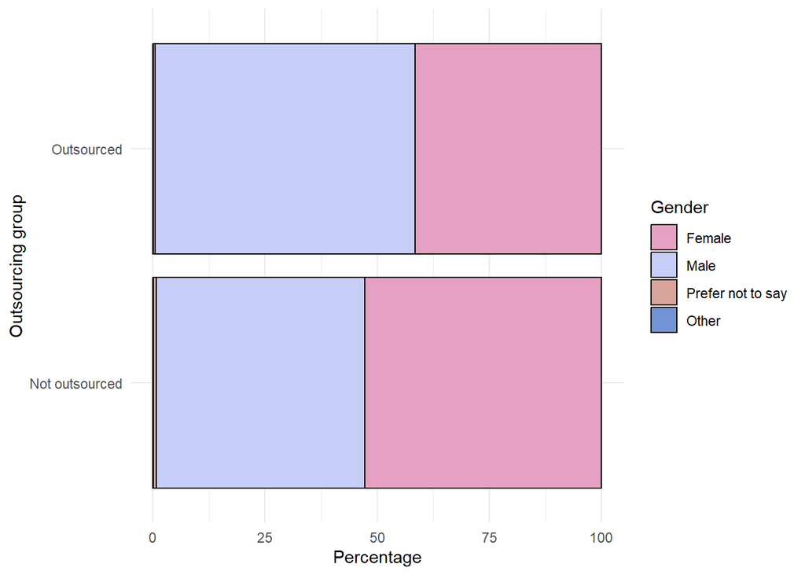

```r
gender_statistics %>%
  ggplot(., aes(outsourcing_status, Percentage, fill = Gender)) +
  geom_col(colour="black") +
  # annotate("text", x = gender_statistics$outsourcing_status, y = 75, label = paste0("n=", gender_statistics$Frequency)) +
  coord_flip() +
  scale_fill_manual(values=colours) +
  theme_minimal() +
  xlab("Outsourcing group")
```

```r
categories <- as.vector(unique(haven::as_factor(data$Gender)))
non_categories <- categories[!(categories %in% "Male")]

# Will throw NA warning. I think this OK but investigate how to avoid the problem
summary_table <- data %>%
  mutate(
    Gender = haven::as_factor(Gender)
  ) %>%
  mutate(
    Gender = forcats::fct_collapse(as.character(Gender),
                                      "Male" = "Male",
                                      "Not male" = non_categories)
  ) %>%
  group_by(outsourcing_status, Gender) %>%
  summarise(
    n = n()
  ) %>%
  mutate(
    Sum = sum(n),
    Percentage = 100 * (n / Sum)
  )

domain <- "Gender"
category_1 <- "Male"
category_2 <- "Not male"

group_1 <- t(tibble("present"=summary_table[which(summary_table[domain]==category_1 &
                                 summary_table["outsourcing_status"]=="Not outsourced"),"n"],
"not present" = summary_table[which(summary_table[domain]==category_2 &
                                 summary_table["outsourcing_status"]=="Not outsourced"),"n"]
))

group_2 <- t(tibble("present"=summary_table[which(summary_table[domain]==category_1 &
                                 summary_table["outsourcing_status"]=="Outsourced"),"n"],
"not present" = summary_table[which(summary_table[domain]==category_2 &
                                 summary_table["outsourcing_status"]=="Outsourced"),"n"]
))


comp_mat <- as.matrix(cbind(group_2, group_1)) # matrix for crosstable
x2 <- gmodels::CrossTable(comp_mat, fisher=TRUE, chisq = TRUE)
```

In terms of Gender, the outsourced group has a larger proportion of males (57.81% compared to 46.4%). This difference is statistically significant; **outsourced workers are 1.58 times more likely to have be male than non-outsourced workers.**

#### Paysplit

```r
gender_summary_paysplit <- data %>%
  group_by(outsourcing_status, income_group, Gender) %>%
  summarise(
    n = n(),
    Frequency = sum(NatRepemployees)
  ) %>%
  mutate(
    N = sum(n),
    Sum = sum(Frequency),
    Percentage = 100 * (Frequency / Sum)
  )

readr::write_csv(ethnicity_statistics, file = "../outputs/data/gender_stats_paysplit_1.csv")
```

```r
mod <- glm(outsourcing_status ~ Gender * income_group, data, family="binomial", weights = NatRepemployees)
summary(mod)
```

```
Call:
glm(formula = outsourcing_status ~ Gender * income_group, family = "binomial",
    data = data, weights = NatRepemployees)

Coefficients:
                                        Estimate Std. Error z value Pr(>|z|)
(Intercept)                             -2.01977    0.06791 -29.741  < 2e-16
GenderMale                               0.56260    0.08168   6.888 5.67e-12
GenderOther                              0.44378    0.96305   0.461   0.6449
GenderPrefer not to say                  0.65109    0.69214   0.941   0.3469
income_groupLow                          0.43123    0.08751   4.928 8.33e-07
GenderMale:income_groupLow              -0.24070    0.11969  -2.011   0.0443
GenderOther:income_groupLow             -0.10606    1.38352  -0.077   0.9389
GenderPrefer not to say:income_groupLow -0.65321    1.10050  -0.594   0.5528

(Intercept)                             ***
GenderMale                              ***
GenderOther
GenderPrefer not to say
income_groupLow                         ***
GenderMale:income_groupLow              *
GenderOther:income_groupLow
GenderPrefer not to say:income_groupLow
---
Signif. codes:  0 '***' 0.001 '**' 0.01 '*' 0.05 '.' 0.1 ' ' 1

(Dispersion parameter for binomial family taken to be 1)

    Null deviance: 8150.5  on 8942  degrees of freedom
Residual deviance: 8076.3  on 8935  degrees of freedom
  (1212 observations deleted due to missingness)
AIC: 9001.4

Number of Fisher Scoring iterations: 4
```

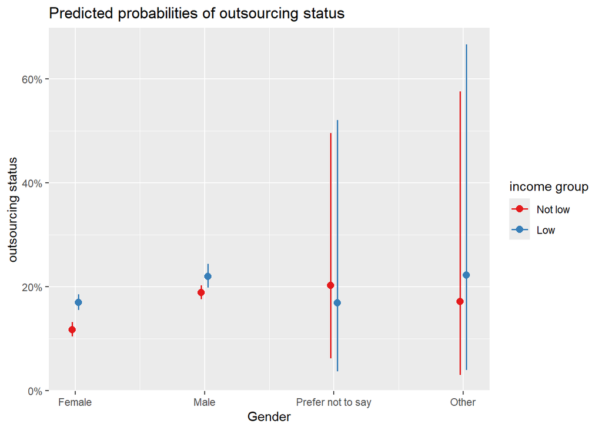

```r
sjPlot::plot_model(mod, type = "int")
```

A glm finds that income group is a significant factor for females but not for males. Whilst males are more likely than females overall to be outsourced, females are significantly more likely to be outsourced if they are in the low income group than if they are in the not-low income group. The plots below show the percentage of outsourced workers by income group and gender.

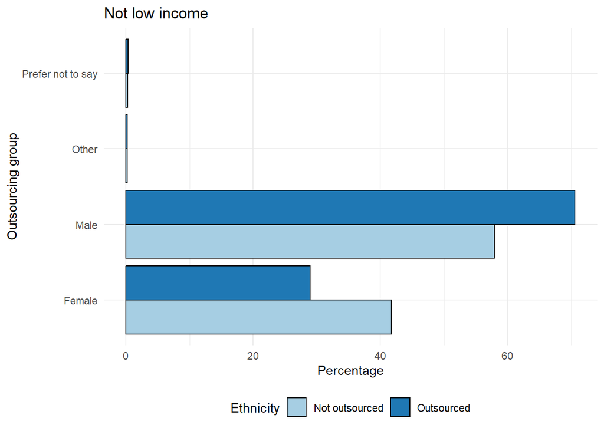

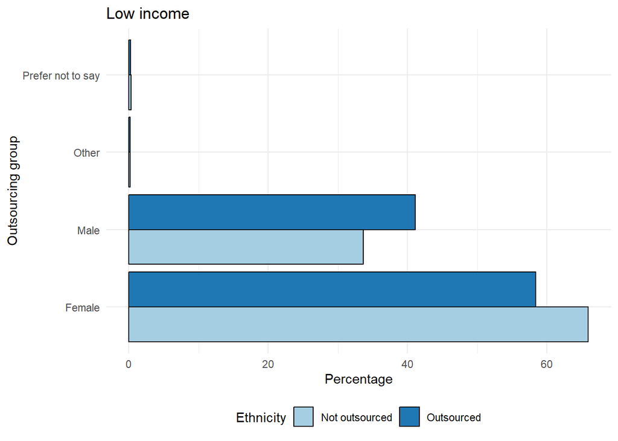

```r
temp_data <-  gender_summary_paysplit %>%
  drop_na(income_group)

for(group in unique(temp_data$income_group)){
  plot_data <- temp_data %>%
    filter(income_group==group)

  plot <- plot_data %>%
    ggplot(., aes(Gender, Percentage, fill = outsourcing_status)) +
      geom_col(colour="black", position = position_dodge()) +
      #annotate("text", x = ethnicity_statistics$outsourcing_status, y = 75, label = paste0("n=",ethnicity_statistics$Sum)) +
      coord_flip() +
      scale_fill_manual(values = many_colours, name = "Ethnicity") +
      xlab("Outsourcing group") +
      theme_minimal() +
    theme(
      legend.position = "bottom"
    ) +
    ggtitle(paste0(group, " income"))


  print(plot)
}
```

### Region[^20]

Let’s cross check the size of the employed workforce across regions, and compare this to how many people are in each region in our sample. The percentages should work out the same if they’re weighted.

The tables below show that our sample is weighted by region. The weighted percentage of our sampled workers in each region matches the percentages from the ONS employment by region tables. This means that the weighted percentage of workers (and therefore outsourced workers) in our sample can be considered to be representative of the national picture.

```r
our_sample <- data %>%
  group_by(Region) %>%
  summarise(
    n = n(),
    sample_sum = sum(NatRepemployees)
  ) %>%
  mutate(
    perc = 100 * (n / sum(n)),
    sample_wtd_perc = 100 * (sample_sum/sum(sample_sum))
  ) %>%
  arrange(desc(sample_wtd_perc))

denoms <- rgn_empl_denoms %>%
  mutate(
    employment_data_perc = 100 * (Employed / sum(Employed))
  ) %>%
  select(-Weight) %>%
  arrange(desc(employment_data_perc))

combined <- merge(denoms,our_sample, by="Region") %>%
  select(c(Region, Employed, sample_sum, employment_data_perc, sample_wtd_perc)) %>%
  arrange(desc(sample_wtd_perc))

# our_sample %>%
#   kable() %>%
#   kable_styling()
#
# denoms %>%
#   kable() %>%
#   kable_styling()

combined %>%
  kable() %>%
  kable_styling()
```

| Region | Employed | sample_sum | employment_data_perc | sample_wtd_perc |
| --- | --- | --- | --- | --- |
| London | 4829298851 | 1431.0519 | 14.557314 | 14.092092 |
| South East | 4753437758 | 1420.8114 | 14.328640 | 13.991250 |
| North West | 3583507881 | 1095.8237 | 10.802034 | 10.790977 |
| West Midlands | 2882955040 | 879.5148 | 8.690305 | 8.660903 |
| Scotland | 2650815533 | 853.0980 | 7.990550 | 8.400768 |
| South West | 2802120873 | 837.8587 | 8.446641 | 8.250701 |
| East Midlands | 2359055655 | 728.1845 | 7.111077 | 7.170699 |
| Wales | 1436559071 | 461.0781 | 4.330327 | 4.540405 |
| North East | 1215820684 | 386.9397 | 3.664938 | 3.810337 |
| Northern Ireland | 873773187 | 275.2233 | 2.633879 | 2.710224 |

The plot below shows the distribution of outsourced and non outsourced workers across regions. It suggests that an outsourced worker is more likely to be based in London than a non-outsourced worker.

```r
region_statistics <- data %>%
  # get values of labels
  # mutate_all(haven::as_factor) %>%
  group_by(outsourcing_status, Region) %>%
  summarise(
    Frequency = sum(NatRepemployees)
  ) %>%
  mutate(
    Sum = sum(Frequency),
    Percentage = 100 * (Frequency / Sum)
  ) %>%
  rename(
    `Outsourcing status` = outsourcing_status
  )

region_statistics %>%
  mutate(
    Region = haven::as_factor(Region)
    ) %>%
  knitr::kable(.,digits = 2) %>%
  kable_styling(full_width = F)
```

| Outsourcing status | Region | Frequency | Sum | Percentage |
| --- | --- | --- | --- | --- |
| Not outsourced | East Midlands | 587.69 | 8446.64 | 6.96 |
| Not outsourced | East of England | 841.35 | 8446.64 | 9.96 |
| Not outsourced | London | 1073.70 | 8446.64 | 12.71 |
| Not outsourced | North East | 333.88 | 8446.64 | 3.95 |
| Not outsourced | North West | 906.43 | 8446.64 | 10.73 |
| Not outsourced | Northern Ireland | 231.66 | 8446.64 | 2.74 |
| Not outsourced | Scotland | 727.28 | 8446.64 | 8.61 |
| Not outsourced | South East | 1232.34 | 8446.64 | 14.59 |
| Not outsourced | South West | 717.36 | 8446.64 | 8.49 |
| Not outsourced | Wales | 377.83 | 8446.64 | 4.47 |
| Not outsourced | West Midlands | 718.03 | 8446.64 | 8.50 |
| Not outsourced | Yorkshire and the Humber | 699.11 | 8446.64 | 8.28 |
| Outsourced | East Midlands | 140.50 | 1708.36 | 8.22 |
| Outsourced | East of England | 125.49 | 1708.36 | 7.35 |
| Outsourced | London | 357.35 | 1708.36 | 20.92 |
| Outsourced | North East | 53.06 | 1708.36 | 3.11 |
| Outsourced | North West | 189.39 | 1708.36 | 11.09 |
| Outsourced | Northern Ireland | 43.56 | 1708.36 | 2.55 |
| Outsourced | Scotland | 125.82 | 1708.36 | 7.37 |
| Outsourced | South East | 188.47 | 1708.36 | 11.03 |
| Outsourced | South West | 120.50 | 1708.36 | 7.05 |
| Outsourced | Wales | 83.25 | 1708.36 | 4.87 |
| Outsourced | West Midlands | 161.49 | 1708.36 | 9.45 |
| Outsourced | Yorkshire and the Humber | 119.46 | 1708.36 | 6.99 |

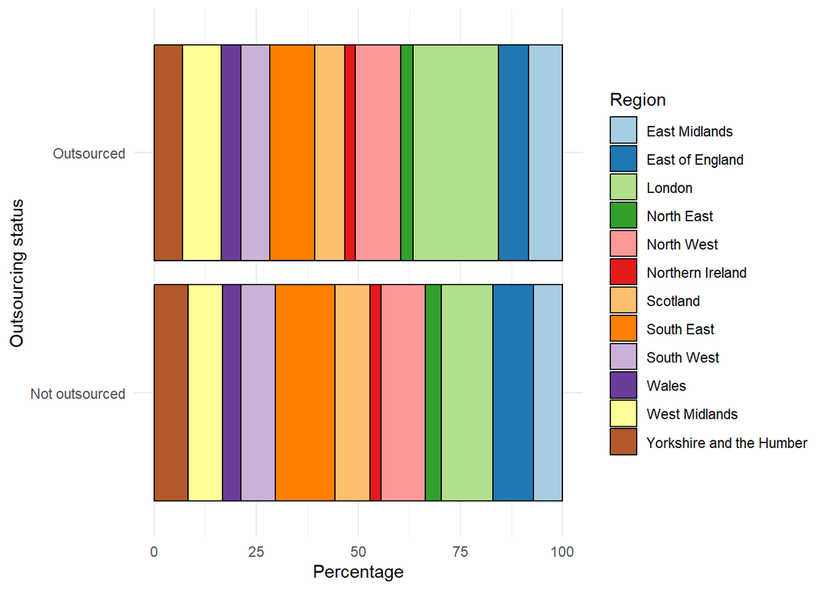

```r
region_statistics %>%
  mutate(
    Region = haven::as_factor(Region)
    ) %>%
  ggplot(., aes(`Outsourcing status`, Percentage, fill = Region)) +
  geom_col(colour="black") +
  coord_flip() +
  scale_fill_manual(values=many_colours) +
  theme_minimal()
```

```r
readr::write_csv(region_statistics, file="../outputs/data/region_statistics.csv")
```

In the plot below the percentages have been scaled to the size of the working population in the region as a function of the total working population in the UK. I need to check whether this scaling is actually necessary, given we are already using weighted data.[^21] Does the weighting process account for region?

Below we calculate the number of outsourced workers within each region.

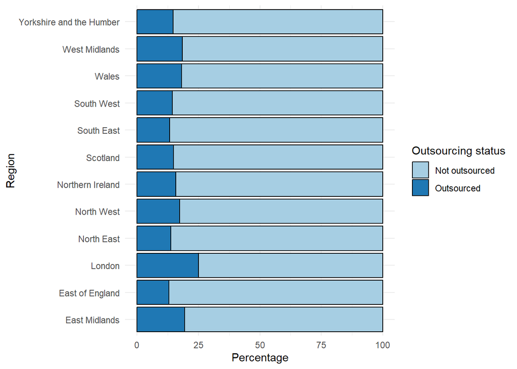

```r
region_statistics_2 <- data %>%
  # get values of labels
  # mutate_all(haven::as_factor) %>%
  group_by(Region, outsourcing_status) %>%
  summarise(
    Frequency = sum(NatRepemployees)
  ) %>%
  mutate(
    Sum = sum(Frequency),
    Percentage = 100 * (Frequency / Sum)
  ) %>%
  rename(
    `Outsourcing status` = outsourcing_status
  )

region_statistics_2 %>%
  ggplot(., aes(Region, Percentage, fill = `Outsourcing status`)) +
  geom_col(colour="black") +
  coord_flip() +
  scale_fill_manual(values=many_colours) +
  theme_minimal()
```

```r
readr::write_csv(region_statistics_2, file = "../outputs/data/region_stats_2.csv")

region_statistics_2_1 <- region_statistics_2 %>%
  filter(`Outsourcing status` == "Outsourced" & Region != "London")

london_perc <- region_statistics_2[which(region_statistics_2$Region == "London" & region_statistics_2["Outsourcing status"] == "Outsourced"), "Percentage"]
```

Visualised on a map:

```r
knitr::include_graphics('../outputs/figures/outsourcing_by_region.svg')
```

[figure not shown]

Visualised on a map, excluding London to enable us to differentiate better between other regions:

```r
knitr::include_graphics('../outputs/figures/outsourcing_by_region_excl_london.svg')
```

[figure not shown]

As we can see, London has the highest proportion of outsourced workers (25%). After London, the regions with the highest proportion of outsourced workers are:

1. East Midlands (19%)
2. West Midlands (18%)
3. Wales (18%)

### Age

#### Outsourcing status

```r
age_statistics <- data %>%
  group_by(outsourcing_status) %>%
  summarise(
    mean = weighted.mean(Age, w = NatRepemployees, na.rm = T),
    median = wtd.quantile(Age, w = NatRepemployees, probs = c(.5), na.rm = T),
    min = wtd.quantile(Age, w = NatRepemployees, probs = c(0), na.rm = T),
    max = wtd.quantile(Age, w = NatRepemployees, probs = c(1), na.rm = T),
    stdev = sqrt(wtd.var(Age, w = NatRepemployees, na.rm = T))
  )

readr::write_csv(age_statistics, file = "../outputs/data/age_stats.csv")
```

As shown in the table below, the median age of the outsourced group is 36 , compared to 43 for the not outsourced group.[^22]

A t-test indicates that on average, **outsourced workers are significantly younger than non-outsourced workers** (*t*(2399.2) = 11.95, *p* = 0).

```r
knitr::kable(age_statistics,
             digits = 2,
             col.names = c("Outsourcing group",
                           "Mean",
                           "Median",
                           "Min",
                           "Max",
                           "Standard dev.")) %>%
  kable_styling(full_width = F)
```

| Outsourcing group | Mean | Median | Min | Max | Standard dev. |
| --- | --- | --- | --- | --- | --- |
| Not outsourced | 42.80 | 43 | 16 | 80 | 13.08 |
| Outsourced | 38.63 | 36 | 16 | 78 | 13.07 |

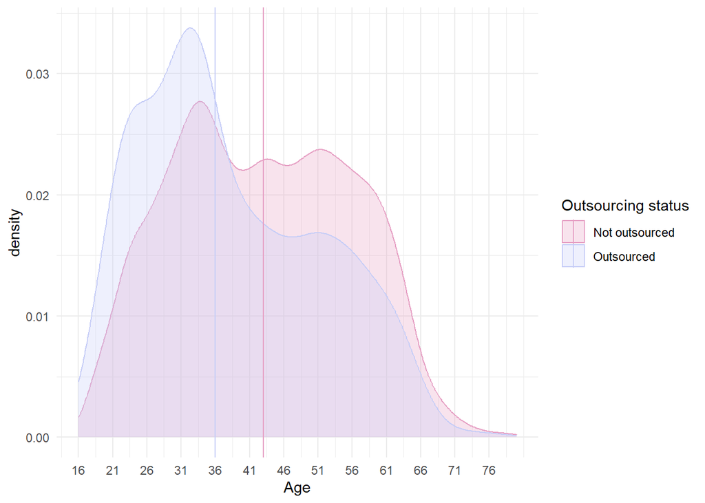

```r
data %>%
  mutate(
    Age = as.numeric(as.character(as_factor(Age)))
  ) %>%
  ggplot(.,aes(Age, colour = outsourcing_status, fill = outsourcing_status)) +
  geom_density(alpha = 0.3) +
  geom_vline(data =age_statistics, aes(xintercept=median, colour = outsourcing_status)) +
  scale_x_continuous(breaks = seq(min(age_statistics$min), max(age_statistics$max),5)) +
  theme_minimal() +
  scale_colour_manual(values=colours, name = "Outsourcing status") +
  scale_fill_manual(values=colours, name = "Outsourcing status")
```

#### Outsourcing group[^23]

```r
age_statistics_2 <- data %>%
  group_by(outsourcing_group) %>%
  summarise(
    mean = weighted.mean(Age, w = NatRepemployees, na.rm = T),
    median = wtd.quantile(Age, w = NatRepemployees, probs = c(.5), na.rm = T),
    min = wtd.quantile(Age, w = NatRepemployees, probs = c(0), na.rm = T),
    max = wtd.quantile(Age, w = NatRepemployees, probs = c(1), na.rm = T),
    stdev = sqrt(wtd.var(Age, w = NatRepemployees, na.rm = T))
  )

readr::write_csv(age_statistics_2, file = "../outputs/data/age_stats_2.csv")
```

Exploring the age distribution for the different outsourced groups, the high density concentration of slightly younger workers identified above appears to be driven primarily by the ‘outsourced’ and ‘high indicator’ groups. The ‘likely agency’ group follows a similar pattern, but has a lower density peak than the other groups, with a higher density of workers of more advanced ages.

```r
knitr::kable(age_statistics_2,
             digits = 2,
             col.names = c("Outsourcing group",
                           "Mean",
                           "Median",
                           "Min",
                           "Max",
                           "Standard dev.")) %>%
  kable_styling(full_width = F)
```

| Outsourcing group | Mean | Median | Min | Max | Standard dev. |
| --- | --- | --- | --- | --- | --- |
| Not outsourced | 42.80 | 43 | 16 | 80 | 13.08 |
| Outsourced | 38.40 | 35 | 16 | 78 | 13.09 |
| Likely agency | 39.80 | 38 | 18 | 77 | 13.49 |
| High indicators | 38.49 | 35 | 18 | 72 | 12.55 |

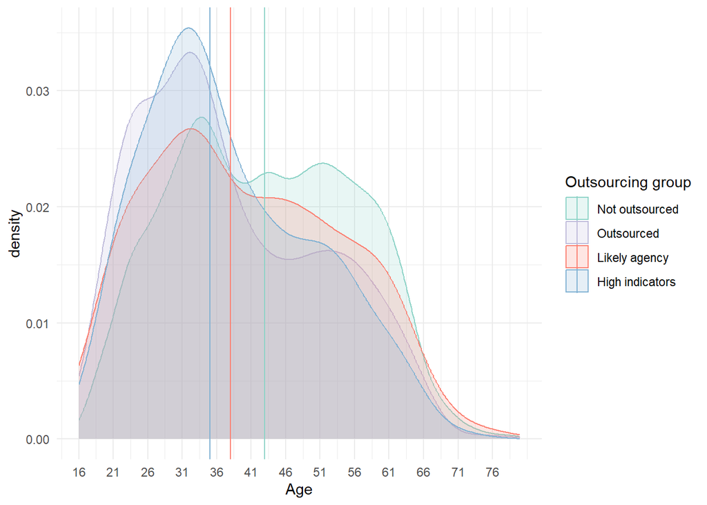

```r
data %>%
  ggplot(.,aes(Age, colour = outsourcing_group, fill = outsourcing_group)) +
  geom_density(alpha = 0.2) +
  geom_vline(data = age_statistics_2, aes(xintercept=median, colour = outsourcing_group)) +
  scale_x_continuous(breaks = seq(min(age_statistics_2$min), max(age_statistics_2$max),5)) +
  theme_minimal() +
  scale_colour_manual(values=better_colours, name = "Outsourcing group") +
  scale_fill_manual(values=better_colours, name = "Outsourcing group")
```

## Footnotes

[^1]: Data file: “outputs/data/total_outsourced.csv”
[^2]: Data file: outputs/data/income_stats.csv
[^3]: Datafile: “../outputs/data/majorgroupcode_summary.csv”
[^4]: Data file: “../outputs/data/majorgroupcode_summary_long.csv” & “../outputs/data/majorgroupcode_summary_wide.csv”)
[^5]: “../outputs/data/elementary_occs_summary.csv”
[^6]: “../outputs/data/process_occs_summary.csv”
[^7]: “../outputs/data/caring_occs_summary.csv”
[^8]: “outputs/data/sector_summary.csv”
[^9]: “outputs/data/sector_summary_2.csv”
[^10]: “outputs/data/sector_summary_3.csv”
[^11]: “outputs/sector_summary_paysplit.csv”
[^12]: Data file: outputs/data/ethnicity_stats_1.csv
[^13]: “outputs/data/ethnicity_stats_paysplit_1.csv”
[^14]: Data file: outputs/data/ethnicity_stats_2.csv
[^15]: “outputs/data/ethnicity_stats_paysplit_1.csv”
[^16]: Data file: outputs/data/ethnicity_stats_2.csv
[^17]: Data file: outputs/data/arrival_in_UK_stats.csv
[^18]: ../outputs/data/interaction_ethnicity_arrival_in_UK_stats.csv
[^19]: Data file: outputs/data/gender_statistics.csv
[^20]: Data file: outputs/data/region_statistics.csv
[^21]: ../outputs/data/region_statistics_weighted.csv
[^22]: Data file: outputs/data/age_stats.csv
[^23]: “outputs/data/age_stats_2.csv”